# Tutorial 3 - Inteligencia Computacional - Regressão Linear e Regularização

Rodrigo Giannotti e Caio Stabel

2024-06-01

## Parte 1: O modelo inicial

O objetivo da primeira parte do tutorial é:

1. avaliar criticamente a base de dados que usamos em nossos problemas de previsão;
2. separar amostras em grupos de treino e teste, avaliando sua compatibilidade;
3. implementar um modelo de regressão linear em R;
4. avaliar a performance de modelos de regressão, observando o efeito de adicionar novas variáveis e transformações;
5. criticar performance do modelo estimado, tento como referência um modelo base.

```r
aluguel <- read_csv("./zap_imoveis_20210701_SUBSET.csv", show_col_types = FALSE)
```

```r
aluguel %>% spec
aluguel %>% head
```

```
## # A tibble: 6 x 7
##   preco_total quartos banheiros suites vagas mobiliado area_util
##         <dbl>   <dbl>     <dbl>  <dbl> <dbl>     <dbl>     <dbl>
## 1        3110       2         2      1     1         0        82
## 2        3400       2         1      0     1         0        53
## 3        2400       2         1      0     1         0        45
## 4        2871       1         1      0     1         1        37
## 5        3400       1         1      1     1         1        38
## 6         860       1         1      0     0         0        45
```

Ajustando a variavel discreta (booleana) mobiliado para ser um fator no R

```r
aluguel %<>% mutate(mobiliado = factor(mobiliado,c(0,1),c('NO','YES')))
aluguel %>% head(5)
```

```
## # A tibble: 5 x 7
##   preco_total quartos banheiros suites vagas mobiliado area_util
##         <dbl>   <dbl>     <dbl>  <dbl> <dbl> <fct>         <dbl>
## 1        3110       2         2      1     1 NO               82
## 2        3400       2         1      0     1 NO               53
## 3        2400       2         1      0     1 NO               45
## 4        2871       1         1      0     1 YES              37
## 5        3400       1         1      1     1 YES              38
```

```r
aluguel %>% summary
```

```
##   preco_total        quartos         banheiros          suites
##  Min.   :   500   Min.   : 0.000   Min.   : 0.000   Min.   : 0.0000
##  1st Qu.:  2900   1st Qu.: 1.000   1st Qu.: 1.000   1st Qu.: 0.0000
##  Median :  3968   Median : 2.000   Median : 1.000   Median : 1.0000
##  Mean   :  6440   Mean   : 2.038   Mean   : 1.998   Mean   : 0.9167
##  3rd Qu.:  7000   3rd Qu.: 3.000   3rd Qu.: 3.000   3rd Qu.: 1.0000
##  Max.   :640000   Max.   :32.000   Max.   :11.000   Max.   :10.0000
##      vagas        mobiliado    area_util
##  Min.   : 0.000   NO :4891   Min.   :  10.0
##  1st Qu.: 1.000   YES:3451   1st Qu.:  40.0
##  Median : 1.000              Median :  62.0
##  Mean   : 1.534              Mean   : 109.5
##  3rd Qu.: 2.000              3rd Qu.: 130.0
##  Max.   :44.000              Max.   :1888.0
```

### QA Parte 1

1. Critique a escolha desta base de dados:
1. liste o problema de negócio e o que esperamos dos dados usados no problema

O problema de negócio nasce da dificuldade de precificar objetivamente o valor de aluguel de um imovel partindo somente de caracteristicas objetivas desse imovel. Temos uma quantidade de variaveis que nos parecem suficientes, mas que com certeza são somente capazes de chegar tão longe na analise deste problema. Nao parece que temos valores faltantes e é necessario estudar mais a fundo, mas parece que todas as variaveis possuem alguns outliers bastante expressivos que pode ser que necessitem de tratamento.

2. liste hipóteses razoáveis para que esta base seja adequada na modelagem do problema

Esperamos encontrar betas positivos para todas as variaveis, mas tambem esperamos encontrar alta correlacao entre muitas delas, de forma que o modelo linear irrestrito pode apresentar betas negativos que podemos ter o interesse de tratar caso exista algum interesse de analise na sensibilidade marginal condicional dos preços às variaveis codificada nos betas.

3. indique outras variáveis que possam ser relevantes mas estão faltando na base.

Nos preocupa de imediato a falta de qualquer informação dos entornos do imovel, fator costumeiramente muito importante para a precificação de imoveis e de seu aluguel. Poderiamos ter, por exemplo, informações censitarias como renda per capita média, n médio de televisores, computadores etc na unidade censitaria que o imovel se localiza. Alem disso também seria interessante ter variaveis que falem sobre o estado de conservacao do imovel, mas entedemos que essas variaveis podem ser dificeis de quantificar.

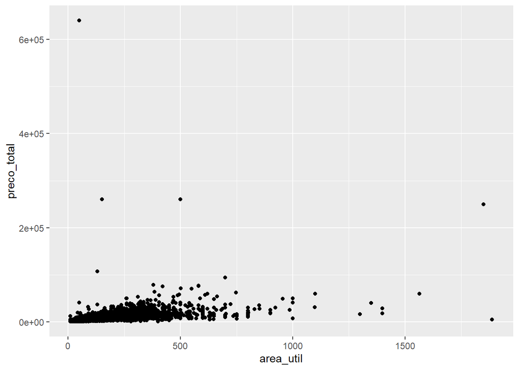

```r
aluguel %>% ggplot(aes(x=area_util, y=preco_total))+geom_point()
```

2. Separe os dados em uma base de treino e outra de teste. Avalie se as estatísticas descritivas das duas amostras estão compatíveis entre si.

```r
set.seed(420)
n <- nrow(aluguel)
ind <- sample(1:n,floor(0.7*n))
treino <- aluguel[ind,]
teste <- aluguel[-ind,]

treino %>% summary
```

```
##   preco_total        quartos        banheiros          suites
##  Min.   :   500   Min.   : 0.00   Min.   : 0.000   Min.   : 0.0000
##  1st Qu.:  2900   1st Qu.: 1.00   1st Qu.: 1.000   1st Qu.: 0.0000
##  Median :  3970   Median : 2.00   Median : 1.000   Median : 1.0000
##  Mean   :  6495   Mean   : 2.04   Mean   : 2.003   Mean   : 0.9168
##  3rd Qu.:  7000   3rd Qu.: 3.00   3rd Qu.: 3.000   3rd Qu.: 1.0000
##  Max.   :640000   Max.   :32.00   Max.   :11.000   Max.   :10.0000
##      vagas       mobiliado    area_util
##  Min.   : 0.00   NO :3418   Min.   :  10.0
##  1st Qu.: 1.00   YES:2421   1st Qu.:  40.0
##  Median : 1.00              Median :  62.0
##  Mean   : 1.54              Mean   : 110.4
##  3rd Qu.: 2.00              3rd Qu.: 130.0
##  Max.   :44.00              Max.   :1888.0
```

```r
teste %>% summary
```

```
##   preco_total        quartos         banheiros          suites
##  Min.   :   500   Min.   : 0.000   Min.   : 0.000   Min.   : 0.0000
##  1st Qu.:  2900   1st Qu.: 1.000   1st Qu.: 1.000   1st Qu.: 0.0000
##  Median :  3960   Median : 2.000   Median : 1.000   Median : 1.0000
##  Mean   :  6314   Mean   : 2.033   Mean   : 1.989   Mean   : 0.9165
##  3rd Qu.:  6800   3rd Qu.: 3.000   3rd Qu.: 3.000   3rd Qu.: 1.0000
##  Max.   :259990   Max.   :18.000   Max.   :11.000   Max.   :10.0000
##      vagas       mobiliado    area_util
##  Min.   : 0.00   NO :1473   Min.   :  10.0
##  1st Qu.: 1.00   YES:1030   1st Qu.:  40.0
##  Median : 1.00              Median :  63.0
##  Mean   : 1.52              Mean   : 107.5
##  3rd Qu.: 2.00              3rd Qu.: 130.0
##  Max.   :10.00              Max.   :1400.0
```

3. Estime um primeiro modelo linear levando em consideração apenas o número de quartos e metragem do imóvel. Este será nosso modelo base, utilizado atualmente pela empresa.

```r
modelin <- lm(preco_total ~ quartos + area_util, treino)
modelin
```

```
##
## Call:
## lm(formula = preco_total ~ quartos + area_util, data = treino)
##
## Coefficients:
## (Intercept)      quartos    area_util
##     2045.65      -163.36        43.31
```

4. Proponha um novo modelo para precificação de aluguel. Lembre-se que podemos fazer transformações e combinações de variáveis.

```r
# montar um modelo que usa mais variaveis e preve o preco do metro quadrado se pa
```

[output not shown]

5. Avalie o ajuste do modelo proposto das formas que discutimos em aula.

```r
# mds nao achei isso desespelo
```

[output not shown]

6. Compare quantitativamente a performance dos dois modelos, indicando qual deles seu grupo considera mais adequado.

```r
# brilha caiao
```

[output not shown]

Dica: avaliando os dados observamos que o aluguel total possui uma cauda à direita bastante pesada, com a grande maioria dos valores concentrados próximos a moda. Pensem em possíveis transformações e remoção de dados que podem ajudar no problema e como isso altera nossa população.

## Parte 2: Mais variáveis e mais modelos

O objetivo da segunda parte do tutorial é:

1. Avaliar erros de treinamento, validação e no conjunto de teste
2. Implementar regularização e seleção de variáveis em modelos lineares
3. Escolher hiperparâmetro usando validação cruzada

```r
aluguel <- read_csv("./zap_add.csv")
```

```
## -------------------------------------------------------- Delimiter: "," dbl
## (208): ...1, preco_total, quartos, banheiros, suites, vagas, mobiliado, ...
```

```r
#aluguel %>% spec

aluguel %<>% mutate(mobiliado = factor(mobiliado,c(0,1),c('NO','YES')))
aluguel %>% head(5)
```

```
## # A tibble: 5 x 208
##    ...1 preco_total quartos banheiros suites vagas mobiliado area_util     X1
##   <dbl>       <dbl>   <dbl>     <dbl>  <dbl> <dbl> <fct>         <dbl>  <dbl>
## 1     1        3110       2         2      1     1 NO               82 -0.337
## 2     2        3400       2         1      0     1 NO               53  0.862
## 3     3        2400       2         1      0     1 NO               45  0.963
## 4     4        2871       1         1      0     1 YES              37  0.356
## 5     5        3400       1         1      1     1 YES              38  1.37
## # i 199 more variables: X2 <dbl>, X3 <dbl>, X4 <dbl>, X5 <dbl>, X6 <dbl>,
## #   X7 <dbl>, X8 <dbl>, X9 <dbl>, X10 <dbl>, X11 <dbl>, X12 <dbl>, X13 <dbl>,
## #   X14 <dbl>, X15 <dbl>, X16 <dbl>, X17 <dbl>, X18 <dbl>, X19 <dbl>,
## #   X20 <dbl>, X21 <dbl>, X22 <dbl>, X23 <dbl>, X24 <dbl>, X25 <dbl>,
## #   X26 <dbl>, X27 <dbl>, X28 <dbl>, X29 <dbl>, X30 <dbl>, X31 <dbl>,
## #   X32 <dbl>, X33 <dbl>, X34 <dbl>, X35 <dbl>, X36 <dbl>, X37 <dbl>,
## #   X38 <dbl>, X39 <dbl>, X40 <dbl>, X41 <dbl>, X42 <dbl>, X43 <dbl>, ...
```

```r
aluguel %>% summary
```

[output not shown]

[output cut: 309 more lines]

[output not shown]

Restringindo domínio de aplicação

```r
aluguel.n <-aluguel %>%
  mutate( preco_m2 = preco_total/area_util) %>%
  filter( quartos <= 6,
          area_util >= 20,
          area_util <= 500,
          preco_m2 < quantile(preco_m2,.99),
          vagas <= 10,
          suites <= banheiros) %>%
  select(-c('...1',preco_m2))

nrow(aluguel.n)/nrow(aluguel)
```

```
## [1] 0.9561256
```

```r
summary(aluguel.n[,1:7])
```

```
##   preco_total       quartos       banheiros          suites
##  Min.   :  500   Min.   :0.00   Min.   : 0.000   Min.   :0.0000
##  1st Qu.: 2900   1st Qu.:1.00   1st Qu.: 1.000   1st Qu.:0.0000
##  Median : 3896   Median :2.00   Median : 1.000   Median :1.0000
##  Mean   : 5890   Mean   :1.99   Mean   : 1.962   Mean   :0.8682
##  3rd Qu.: 6650   3rd Qu.:3.00   3rd Qu.: 3.000   3rd Qu.:1.0000
##  Max.   :75200   Max.   :6.00   Max.   :10.000   Max.   :5.0000
##      vagas        mobiliado    area_util
##  Min.   : 0.000   NO :4658   Min.   : 20.0
##  1st Qu.: 1.000   YES:3318   1st Qu.: 40.0
##  Median : 1.000              Median : 62.0
##  Mean   : 1.455              Mean   :100.1
##  3rd Qu.: 2.000              3rd Qu.:125.0
##  Max.   :10.000              Max.   :500.0
```

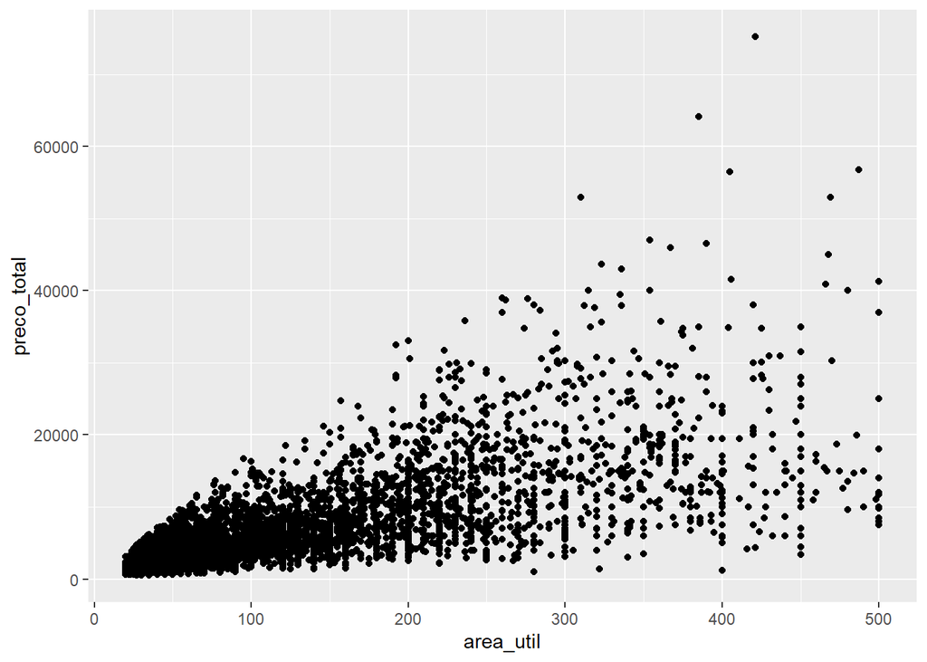

```r
aluguel.n %>% ggplot(aes(x=area_util, y=preco_total))+geom_point()
```

```r
aluguel.n %<>%
  mutate(
    logarea_util = log(area_util),
    logpreco_total = log(preco_total)) %>%
  select(-c(preco_total,area_util))
colnames(aluguel.n)
```

```
##   [1] "quartos"        "banheiros"      "suites"         "vagas"
##   [5] "mobiliado"      "X1"             "X2"             "X3"
##   [9] "X4"             "X5"             "X6"             "X7"
##  [13] "X8"             "X9"             "X10"            "X11"
##  [17] "X12"            "X13"            "X14"            "X15"
##  [21] "X16"            "X17"            "X18"            "X19"
##  [25] "X20"            "X21"            "X22"            "X23"
##  [29] "X24"            "X25"            "X26"            "X27"
##  [33] "X28"            "X29"            "X30"            "X31"
##  [37] "X32"            "X33"            "X34"            "X35"
##  [41] "X36"            "X37"            "X38"            "X39"
##  [45] "X40"            "X41"            "X42"            "X43"
##  [49] "X44"            "X45"            "X46"            "X47"
##  [53] "X48"            "X49"            "X50"            "X51"
##  [57] "X52"            "X53"            "X54"            "X55"
```

[output cut: 37 more lines]

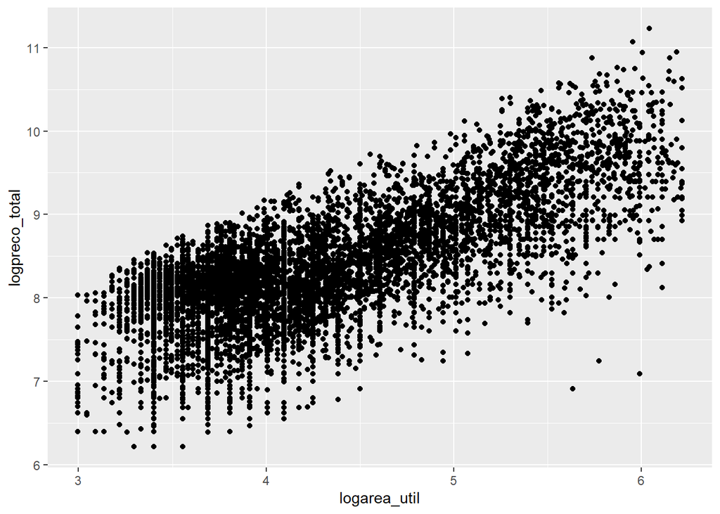

```r
aluguel.n %>% ggplot(aes(x=logarea_util, y=logpreco_total))+geom_point()
```

10-fold crossvalidation

```r
library(caret)
# https://topepo.github.io/caret/model-training-and-tuning.html#the-traincontrol-function
train_ctrl <- trainControl(
  method = "cv", # "loocv", "repeated cv", ..
  number = 10
)
```

train test split

```r
set.seed(420)
n <- nrow(aluguel.n)
ind <- sample(1:n,floor(0.7*n))
treino <- aluguel.n[ind,]
teste <- aluguel.n[-ind,]
```

```r
# a escolha de grid pode ser iterativa no sentido de ajustar o range de busca
grid <- expand.grid(.alpha=1,.lambda=exp(seq(-6, -3, by=0.05)))
```

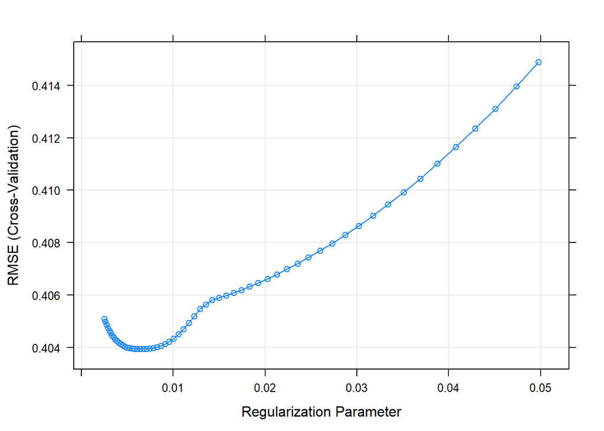

```r
# using caret to perform crossvalidation in LASSO
set.seed(420)
mod1 <- train( logpreco_total ~ .,
               data = treino,
               method =  "glmnet",
               trControl = train_ctrl,
               metric = "RMSE", # metrica que desejo minimizar
               preProc = c("center","scale"),
               tuneGrid = grid,
               family = "gaussian")
plot(mod1)
```

```r
# variaveis selecionadas
coef(mod1$finalModel,mod1$bestTune$lambda)
```

```
## 207 x 1 sparse Matrix of class "dgCMatrix"
##                         s1
## (Intercept)   8.385346e+00
## quartos      -5.500865e-02
## banheiros     3.469324e-02
## suites        1.588890e-01
## vagas         9.625857e-02
## mobiliadoYES  1.667464e-01
## X1            .
## X2            .
## X3            .
## X4            .
## X5            .
## X6            .
## X7            .
## X8            .
## X9           -2.024794e-03
## X10           4.450765e-03
## X11           .
## X12           .
## X13           2.389346e-03
## X14           .
## X15           .
## X16           .
## X17           .
## X18           .
## X19           .
## X20          -9.523954e-04
## X21           .
## X22           .
## X23          -1.885911e-03
## X24           .
## X25           .
## X26          -1.637012e-03
## X27           .
## X28           .
## X29           .
## X30          -3.495214e-03
## X31           .
## X32           .
```

[output cut: 154 more lines]

```
## X187          .
## X188          2.917848e-03
## X189          .
## X190          .
## X191          .
## X192         -2.905423e-03
## X193          1.852675e-03
## X194          .
## X195          1.199295e-03
## X196          .
## X197          .
## X198          .
## X199          .
## X200          .
## logarea_util  4.415250e-01
```

```r
# previsao de valores fora da amostra e avaliação do erro
yhat <- predict(mod1, newdata = teste)
```

```r
#falta plotar os residuos para avaliar sua performance y vx yhat, regressão, etc.
```

[output not shown]